# Wildfires in BC

Orson Nickson

2022-11-29

# Introduction

This report is about wildfires in BC. This report seeks to answer how much temperature affects how dangerous fires can become, when fires are the most prevalent and how dangerous they are, whether the weather affects fires at all, and where they are in BC. By answering these questions this report hopes to educate people on what can be done to improve our knowledge of wildifres in BC. This report will also illustrate what will happen in the future as our climate continues to warm, the incidence of dangerous fires would be expected to increase.

# Data

The data was published by the BC Wildfire Service. The data used in this analysis came in the format of 2 csv files. The first file was 2.7 million weather station observations. The second file was a list of stations, the station names, and where they are located in coordinates. The data used in this analysis is weather data that includes the date of the observation, the amount of precipitation, the temperature, wind speed, the danger rating of any fire reported, and the station ID. All of this data is collected from weather stations all over BC. Other data used included shape file data from CanCensus to create maps of British Columbia.

# Summary Statistics

Summary Statistics

| Variable | N | Mean | Std. Dev. | Min | Pctl. 25 | Pctl. 75 | Max |
| --- | --- | --- | --- | --- | --- | --- | --- |
| PRECIPITATION | 46813 | 0.089 | 0.488 | 0 | 0 | 0 | 13.5 |
| TEMPERATURE | 46813 | 16.809 | 7.958 | -15.1 | 11 | 22.3 | 44.5 |
| WIND_SPEED | 46813 | 8.61 | 4.807 | 0 | 5.5 | 10.7 | 64 |
| DANGER_RATING | 46813 | 2.515 | 1.279 | 1 | 1 | 4 | 5 |

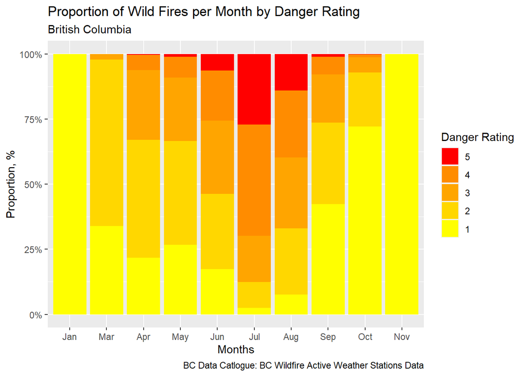

This figure shows the proportion of fires of each danger rating in each month. In the months of January and November all the fires had a danger rating of 1. There were no fires reported in February or December. This makes sense as it is very cold and there are less people camping, which could be a source of fires. There were only 3 reports of fires in January and 11 reports of fires in November, compared to the hundreds of reports of fires in the other months of the year. As you can see the summer months have the highest reports of dangerous fires. As the climate continues to warm we might expect to see more dangerous fires being reported in the spring and fall seasons.